# Lecture 7: User-defined Functions

## I. Import Libraries

```python
# the "numPy" library is used for mathematical operations
# the "matplotlib" library is for generating graphs
# the "pandas" library is for manipualting datasets

import numpy as np
import matplotlib.pyplot as plt
import pandas as pd
```

## II. Introduction to Functions

A function is ...

- a **block of reusable** code to perform a a specific task
- Functions avoid repetition
- As our code grows larger, functions make it more manageable

"Built-in" functions are those from Python libraries, e.g.

`print()`, `type()`, `round()`,`abs()`, `len()`

- The "arguments" are the values of the inputs
- The "return" is the output

```python
# Argument:   "Hello"
# Return:     Showing the message on screen

print("Hello "+str(24))
# each function has an argument and return
```

```
Hello 24
```

```python
# Argument:  3.14
# Return:    The type of object, e.g. int, str, boolean, float, etc.

type("ABC")
```

```
str
```

```python
# First Argument:   np.pi     (a numeric value)
# Second Argument:  6         (the number of decimals)
# Return:  Round the first argument, given the number of decimals in the second argument

round(np.pi,  10) # np.pi = how to represent pi in python
```

```
3.1415926536
```

```python
# Argument: -4
# Return:   The absolute value
abs(-4)
```

```
4
```

```python
list_fruits = ["Apple","Orange","Pear"]

# Argument: list_fruits
# Return:   The number of elements in the list
len('Hello')
```

```
5
```

Enter arguments by assigning parameters

```python
# Here "df" and "size" are both parameters
# They get assigned the arguments "2" and "20", respectively
# The return is a vector of random variables

vec_x = np.random.chisquare(df = 2, size = 20)
```

```python
vec_x
```

```
array([0.29024352, 5.14493607, 1.7753455 , 0.80769481, 0.08278953,
       1.31461266, 0.31455993, 5.00521641, 0.71735186, 0.96627487,
       0.26991529, 2.6440828 , 1.94239222, 0.66301317, 1.25371815,
       0.41108593, 0.81775308, 1.51710962, 0.61731137, 0.51220296])
```

```python
vec_y = np.random.normal(loc = 2, scale = 1, size = 20)
vec_z = np.random.uniform(low = -2, high =2, size = 50) # location, scale, and size
```

```python
print(vec_y)
vec_z
```

```
[-0.68652047  2.66464167  3.17914715  1.49040128  1.99931873  2.92812858
  0.82734156  0.47751481  0.87120952  0.67038847  1.68153095  2.84994208
  0.93798341  1.87107336  2.38976907  2.27361432 -0.12022412  2.97778584
  0.74656329  4.39263619]
```

```
array([ 0.49763118, -1.70963319, -1.16665479, -1.66842656,  0.24829302,
       -1.11288116, -1.75608874,  1.21405947, -1.84492193, -0.92504477,
       -1.30556477,  0.4537902 , -1.11623459,  1.50067327, -1.74301821,
       -0.06201596, -1.84048264,  0.52304291, -0.88309205,  1.69747239,
        0.03934232, -1.6861197 ,  1.60027293,  1.55257603, -0.42483668,
       -1.28904996,  1.94775124, -0.8388682 ,  1.35111895, -1.52648565,
       -1.70977692,  0.95775495,  1.84970577,  0.95024168, -0.97664339,
       -1.26959251,  0.20437919,  1.087485  , -1.45167706, -0.96840218,
        1.97647323,  1.48986769,  0.07025823, -1.00379583, -1.08074468,
       -1.9740823 , -0.56811212,  1.00026208, -0.89465612,  0.39099985])
```

Discussion:

- What are the parameters, arguments, and returns above?

## III. Custom Functions

You can write your own functions:

```
#---- DEFINE
    def my_function(parameter):
        body
        return expression

    #---- RUN
    my_function(parameter = argument)

    #---- RUN
    my_function(argument)
```

Example: Calculate

$V=P\left(1+{\frac {r}{n}}\right)^{nt}$

```python
# We are going to define a function "fn_compute_value"
# You can choose any name
# Using prefixes like "fn_" can help you remember this is a "function" object
# What are the parameters?

# this structure is minimal, it takes the minimum # of arguments. we need to take input, tell the computer what it does, and give an output.
# can run the function with a keyword argument or without a keyword argument.

def function_v(P, r,n, t): # function_v requires 4 arguents
    v = P*(1+(r/n))**(n*t)
    return v
```

```python
function_v(P=100, r = 0.01, n = 20, t=10)
```

```
110.51432983541218
```

```python
# You can know compute the formula with different values

V1 = function_v(P = 1000, r = 0.01, n = 20, t=10)
V2 = function_v(P = 10, r = 0.01, n = 20, t=10)

print(V1)
print(V2) # variables can contain a function with specific arguments
```

```
1105.1432983541217
11.051432983541218
```

Try it yourself:

- Write a function that calculates

$f(x) = x^2 + 2x + 1$.

```python
# Write your own code here

def f1(x):
    y = x**2 + 2*x +1
    return y

def f2(x):
    v = x**7 + 6*x + 7
    return v

#def f3(a, b):
    for num in f3:
        n = 5*x
        return x
    # not iterable, a function only takes specific values. iterable things like lists go through one value after another

def f4(x, y):
    b = x**y + x*y # returns none until i put what value specifically to return
    return b + 1

def f5(x, y):
    b = x**y + x*y # returns none until i put what value specifically to return
    return b + 2


print(f1(5))
print(f1(6))

print(f2(5))
print(f2(6))

print(f4(4, 5))
print(f5(4, 5))
```

```
36
49
78162
279979
1045
1046
```

Try it yourself: Write a function

- with a parameter "numeric_grade"
- Inside the function write an

if/else statement for grade $\ge 55$.

- If it's true, then assign "status = pass"
- If it's false, then assign "status = fail"
- Return the value of "status"

```python
# Write your own code
```

Try it yourself! Write a function

- Write a function with parameters

"first_name", "last_name", "car_model"

- Return a message saying:

"Dear customer {first_name} {last_name},  
your car model {car_model} is ready"

```python
# Write your own code

def carfunc(first_name, last_name, car_model):
    return "Dear customer" + first_name + last_name + "your car model" + car_model + "is ready"
    print("Dear customer" + first_name + last_name + "your car model" + car_model + "is ready")

carfunc(turtle, theena,  benz)
```

```
---------------------------------------------------------------------------
NameError                                 Traceback (most recent call last)
Cell In[27], line 9
      6     return "Dear customer" + first_name + last_name + "your car model" + car_model + "is ready"
      7     print("Dear customer" + first_name + last_name + "your car model" + car_model + "is ready")
----> 9 carfunc(turtle, theena,  benz)

NameError: name 'turtle' is not defined
```

## III. Lambda Functions

"Lambda Functions" are defined in one line:

```
my_function = lambda parameters: expression
```

Example: Calculate $x + y + z$

```python
# (a) Define function
fn_sum = lambda x,y,z: x + y + z

# (b) Run function
fn_sum(1,2,3)

#system names show up in blue
```

```
6
```

Example: Calculate

$V=P\left(1+{\frac {r}{n}}\right)^{nt}$

```python
fn_v = lambda P, r, n, t: P*(1+(r/n))**(n*t) # is good to use lambda function when we hve a shorter mathematical function
```

```python
V1 = fn_v(P = 1000, r = 0.01, n = 20, t=10)
V2 = fn_v(P = 10, r = 0.01, n = 20, t=10)

print(V1)
print(V2)
```

```
1105.1432983541217
11.051432983541218
```

Try it yourself!

(a) Boleean + Functions

- Write a function called "fn_iseligible_vote"
- This functions returns a boolean value

that checks whether age $\ge$ 18

```python
# Write your own code
```

[output not shown]

(b) Looping + Functions

- Create list_ages = [18,29,15,32,6]
- Write a loop that checks whether above ages are eligible to vote
- Use the above function

```python
# Write your own code

list_ages = [18,29,15,32,6]

for age in list_ages:
    print("Age " + str(age) + " is eligible? " + str(fn_iseligible_vote(age)))
```

```
Age 18 is eligible? True
Age 29 is eligible? True
Age 15 is eligible? False
Age 32 is eligible? True
Age 6 is eligible? False
```

## IV. (Optional) Functions for visualization

Returning a value is not always necesary, you can write:

```
#---- DEFINE
    def my_function(parameter):
        body
```

Example: A customized plot

- You can use functions to store your favorite aesthetic

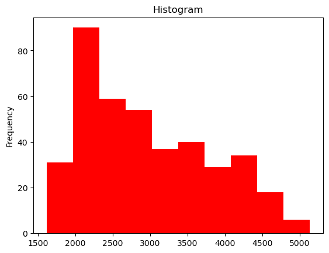

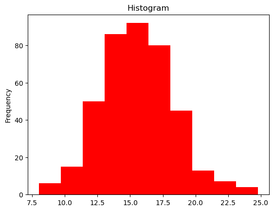

```python
# Define the function
def red_histogram(vec_x,title):
    plt.hist(x = vec_x, color = "red")
    plt.title(title)
    plt.ylabel("Frequency")
    plt.show()

carfeatures = pd.read_csv("data/features.csv")

red_histogram(vec_x = carfeatures["weight"], title = "Histogram")
red_histogram(vec_x = carfeatures["acceleration"], title = "Histogram")
```

Try it yourself!

Create a function that computes a red scatter plot  
that takes $y$ and $x$ inputs

```python
# Write your own code
# Define the function
```